# examples_0416

An alien society uses a base-6 positional numbering system. Luckily, they use the same symbol "0" for zero, and then symbols that match our uppercase letters. Below represents their single-digit addition table.

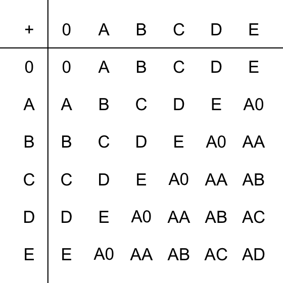

Use that table to add:

ACCD + D0E

The answer is `BADC`.

Use that table to add:

EEE + DBC

Use that table to add:

An alien society uses a base-8 positional numbering system. Luckily, they use the same symbol "0" for zero, and then symbols that match our uppercase letters. Below represents their single-digit addition table.

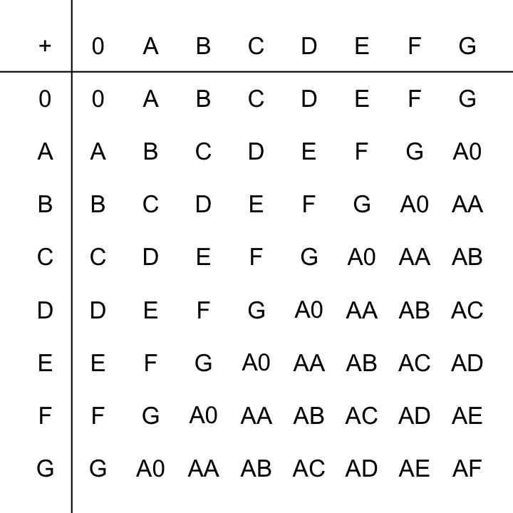

Use that table to add:

CDF + FEE

The answer is `ABBC`.

An alien society uses a base-8 positional numbering system. Luckily, they use the same symbol "0" for zero, and then symbols that match our uppercase letters. Below represents their single-digit addition table.

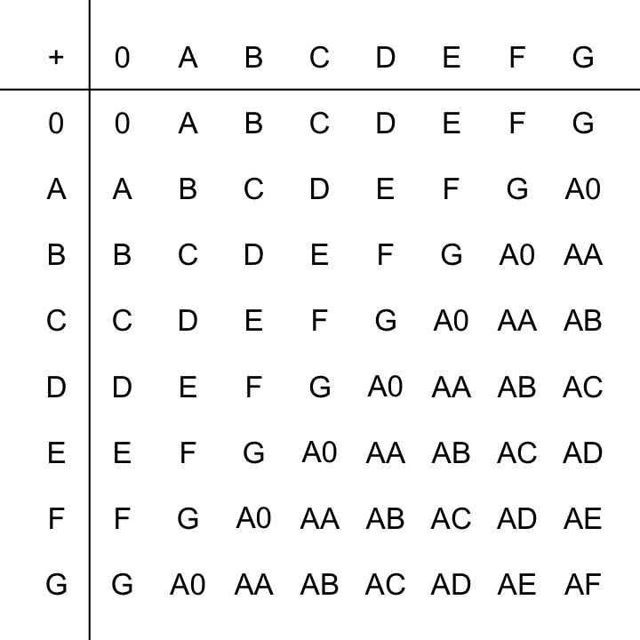

Use that table to add:

DED + CCG

The answer is `A0AC`.

An alien society uses a base-6 positional numbering system. Luckily, they use the same symbol "0" for zero, and then symbols that match our uppercase letters. Below represents their single-digit addition table.

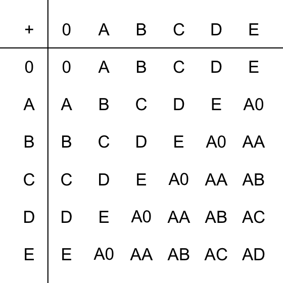

Use that table to add:

AEBA + A0ED

The answer is `C0AE`.

An alien society uses a base-9 positional numbering system. Luckily, they use the same symbol "0" for zero, and then symbols that match our uppercase letters. Below represents their single-digit addition table.

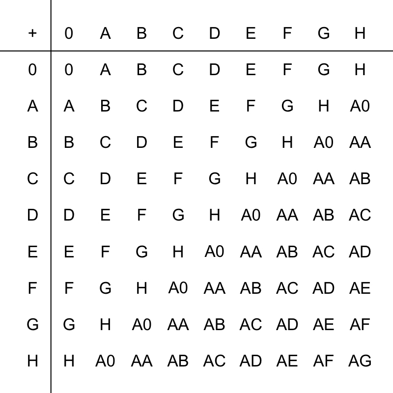

Use that table to add:

C0E + CGH

The answer is `FHD`.

Use that table to add:

CAA + F0C

Use that table to add:

AABB + BEF

An alien society uses a base-9 positional numbering system. Luckily, they use the same symbol "0" for zero, and then symbols that match our uppercase letters. Below represents their single-digit addition table.

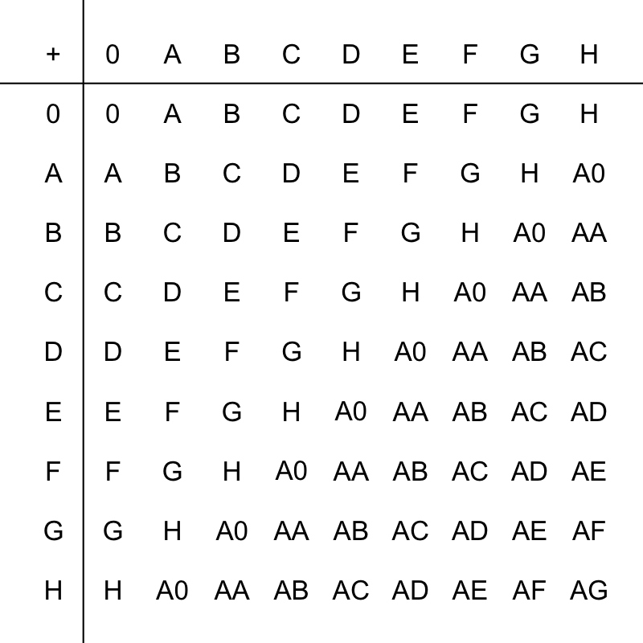

Use that table to add:

EED + D0F

The answer is `A0FA`.

An alien society uses a base-6 positional numbering system. Luckily, they use the same symbol "0" for zero, and then symbols that match our uppercase letters. Below represents their single-digit addition table and single-digit multiplication table.

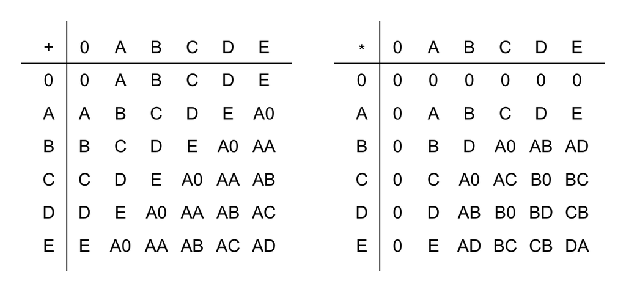

Use those tables to multiply:

D0A * BCD

The answer is `ADC0CD`.

An alien society uses a base-6 positional numbering system. Luckily, they use the same symbol "0" for zero, and then symbols that match our uppercase letters. Below represents their single-digit addition table and single-digit multiplication table.

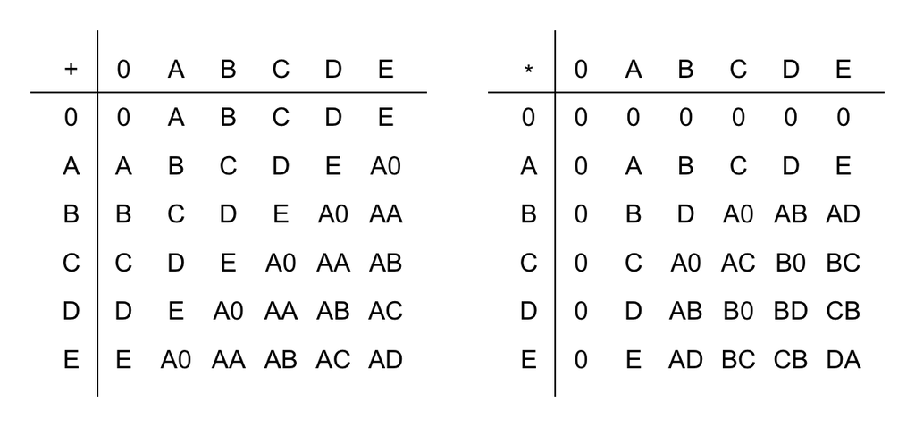

Use those tables to multiply:

BBA * EAC

The answer is `B0BBAC`.

An alien society uses a base-5 positional numbering system. Luckily, they use the same symbol "0" for zero, and then symbols that match our uppercase letters. Below represents their single-digit addition table and single-digit multiplication table.

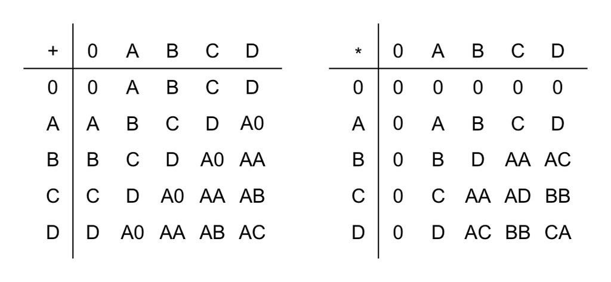

Use those tables to multiply:

D0C * CDD

The answer is `CAABDB`.

An alien society uses a base-7 positional numbering system. Luckily, they use the same symbol "0" for zero, and then symbols that match our uppercase letters. Below represents their single-digit addition table and single-digit multiplication table.

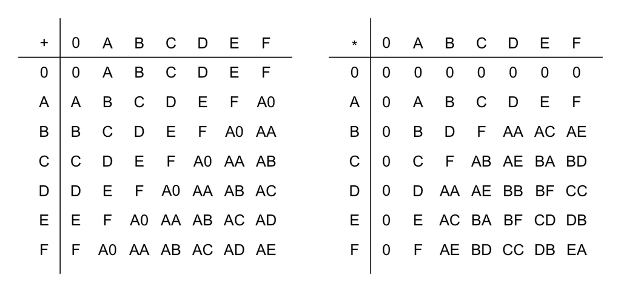

Use those tables to multiply:

BAF * A0E

The answer is `BCCBB`.

An alien society uses a base-7 positional numbering system. Luckily, they use the same symbol "0" for zero, and then symbols that match our uppercase letters. Below represents their single-digit addition table and single-digit multiplication table.

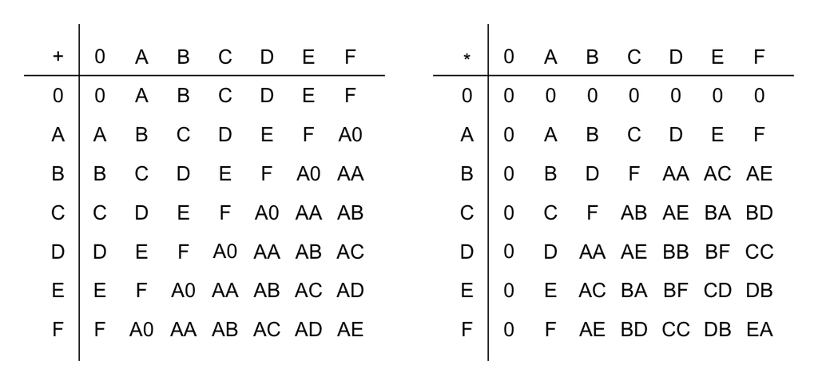

Use those tables to multiply:

BBE * CCC

The answer is `AABBBA`.

An alien society uses a base-8 positional numbering system. Luckily, they use the same symbol "0" for zero, and then symbols that match our uppercase letters. Below represents their single-digit addition table and single-digit multiplication table.

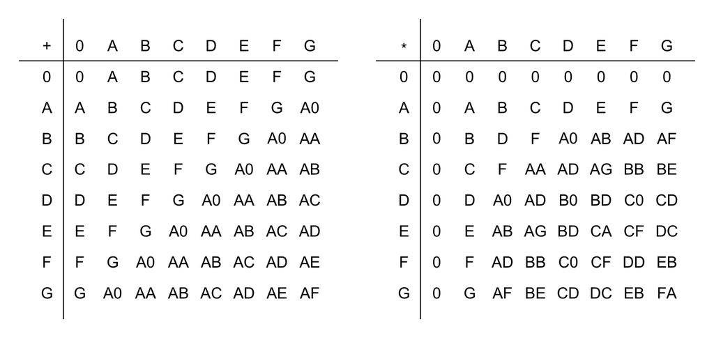

Use those tables to multiply:

GC * B0E

The answer is `AGBDG`.

An alien society uses a base-8 positional numbering system. Luckily, they use the same symbol "0" for zero, and then symbols that match our uppercase letters. Below represents their single-digit addition table and single-digit multiplication table.

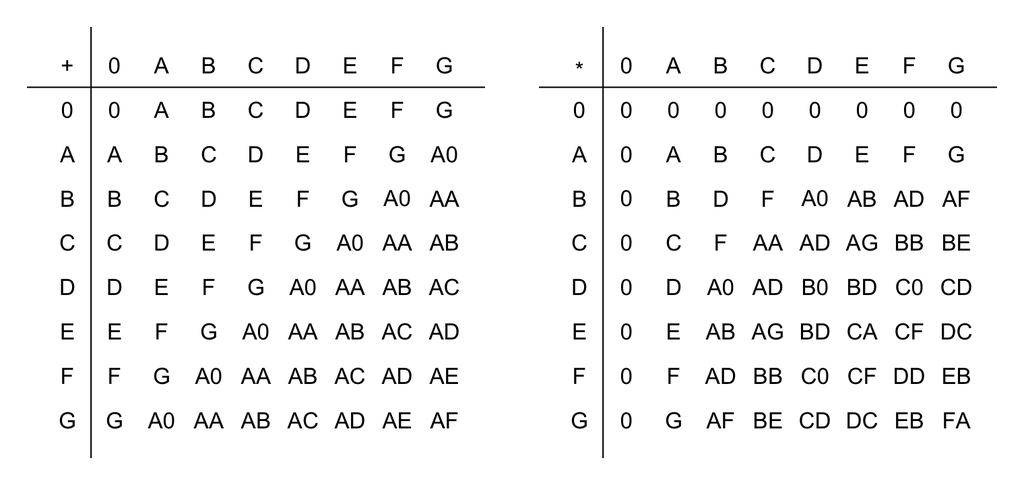

Use those tables to multiply:

ABC * AAG

The answer is `ADFCE`.

Use those tables to multiply:

AGE * BBD

Use those tables to multiply:

AED * AGB

Use those tables to multiply: